# Question

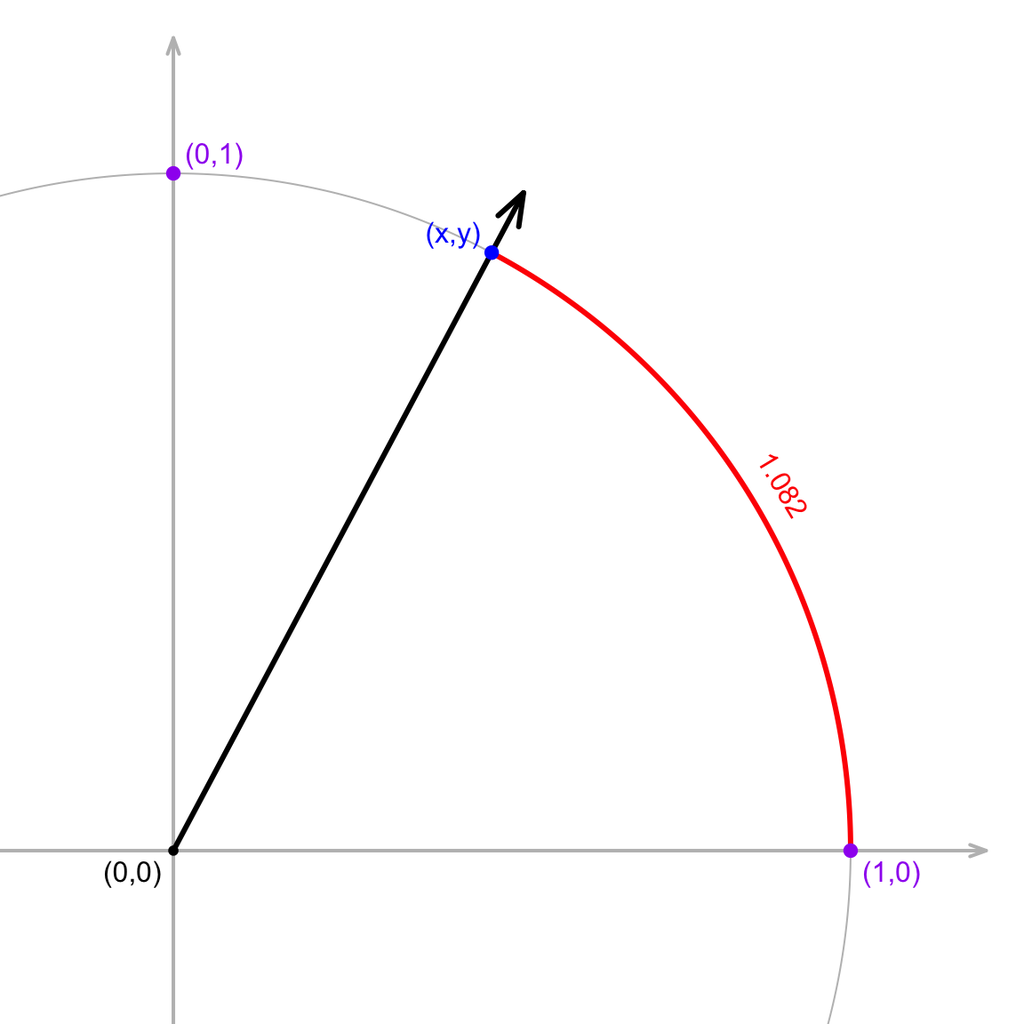

Find the coordinates of the point.

- $x=$ ##ANSWER1##
- $y=$ ##ANSWER2##

Find the slope of the ray that connects the origin to the point.

- slope = ##ANSWER3##

## Answerlist

- 0.056
- 0.47
- 0.532
- 0.883
- 1.082
- 1.879
- 3.177
- 5.899
- 16.02
- 0.056
- 0.47
- 0.532
- 0.883
- 1.082
- 1.879
- 3.177
- 5.899
- 16.02
- 0.056
- 0.47
- 0.532
- 0.883
- 1.082
- 1.879
- 3.177
- 5.899
- 16.02

# Solution

Notice, you can draw a right triangle with a hypotenuse of length 1. Also, remember that the angle measure (in radians) is equivalent to the arc length on the unit circle.

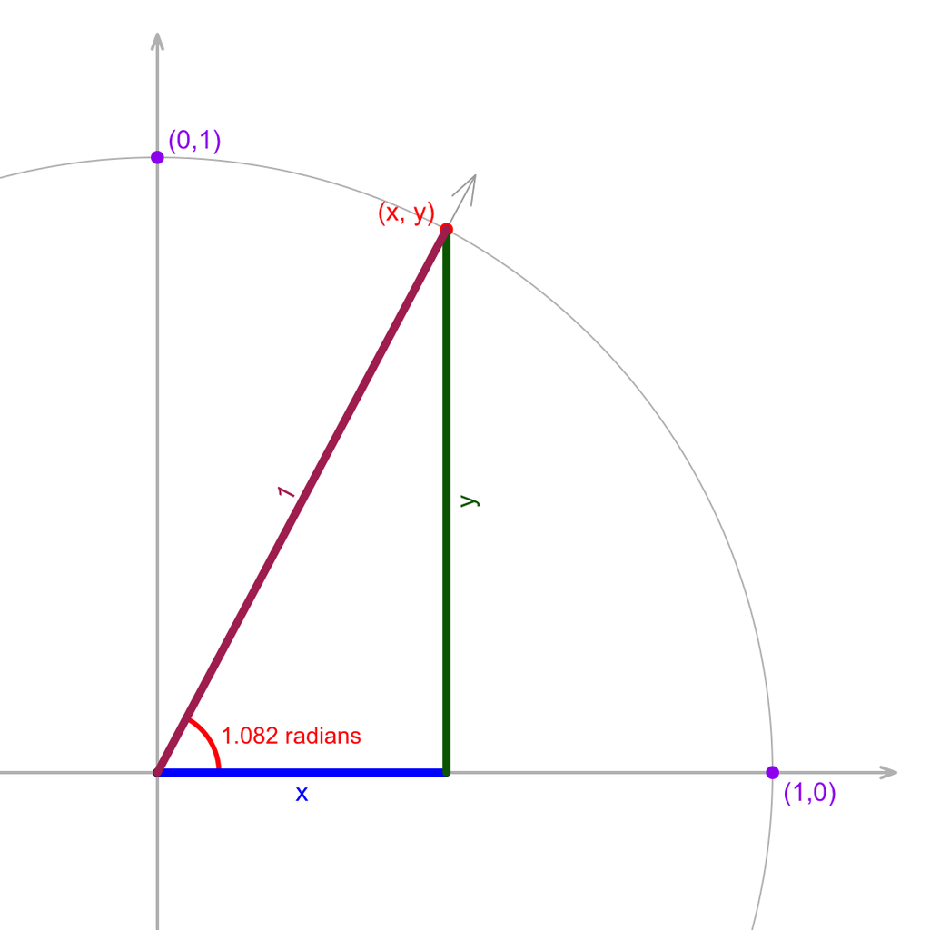

Use [SOHCAHTOA](https://en.wikipedia.org/wiki/Mnemonics_in_trigonometry#SOH-CAH-TOA) to find the answers.

Find $x$.

$$\cos(1.082) ~=~ \frac{x}{1}$$

$$0.47 ~=~ x$$

Find $y$.

$$\sin(1.082) ~=~ \frac{y}{1}$$

$$0.883 ~=~ y$$

Find the slope. Notice, since the ray goes through $(0,0)$, the slope, which is rise over run, is simply $y/x$. Surprisingly, maybe, this is the same thing as $\tan(\theta)$.

$$\tan(1.082) ~=~ \text{slope} ~=~
\frac{y}{x} ~=~ \frac{\sin(1.082)}{\cos(1.082)}$$

$$1.879 ~=~ \text{slope}$$

# Meta-information

extype: cloze exclozetype: schoice|schoice|schoice exsolution: 010000000|000100000|000001000 exname: pnt_n_slope_from_ang_Q1